# Binary Classification Model for Diabetes Readmission Prediction Using R Take 3

David Lowe

May 17, 2019

Template Credit: Adapted from a template made available by Dr. Jason Brownlee of Machine Learning Mastery. [http://machinelearningmastery.com/]

INTRODUCTION: Management of hyperglycemia in hospitalized patients has a significant bearing on outcome, in terms of both morbidity and mortality. However, there are few national assessments of diabetes care during hospitalization which could serve as a baseline for change. This analysis of a large clinical database was undertaken to provide such an assessment and to find future directions which might lead to improvements in patient safety. The statistical model suggests that the relationship between the probability of readmission and the HbA1c measurement depends on the primary diagnosis. The data suggest further that the greater attention to diabetes reflected in HbA1c determination may improve patient outcomes and lower cost of inpatient care.

In iteration Take1, we established the baseline prediction accuracy for further takes of modeling. To limit the processing time and memory requirements, we also limited the attributes used for this project by not including those attributes that do not appear on the final model of the research paper.

In iteration Take2, we further tested the machine learning models by rearranging some of the features to be more consistent with the research paper (Table 4). We had hoped to improve the overall accuracy and applicability of the model by having features with a fewer number of categories.

In this iteration, we will test the machine learning models by reconfiguring the target variable to have only two categories, thus making this a binary classification exercise. We hope to improve the overall accuracy applicability of the model by predicting with just the “yes” and “no” outcomes.

ANALYSIS: The baseline performance of the machine learning algorithms achieved an average accuracy of 61.82%. Two algorithms (Logistic Regression and Gradient Boosting) achieved the top accuracy metrics after the first round of modeling. After a series of tuning trials, Gradient Boosting turned in the top overall result and achieved an accuracy metric of 63.05%. By using the optimized parameters, the Gradient Boosting algorithm processed the testing dataset with an accuracy of 62.96%, which was slightly below the prediction accuracy using the training data.

CONCLUSION: Restructuring the target variable to binary outcomes yielded accuracy improvement and a reduction in the processing time. For this iteration, the Gradient Boosting algorithm achieved the overall results using the training and testing datasets. For this dataset, Gradient Boosting should be considered for further modeling or production use.

Dataset Used: Diabetes 130-US hospitals for years 1999-2008 Data Set

Dataset Reference: https://archive.ics.uci.edu/ml/datasets/Diabetes+130-US+hospitals+for+years+1999-2008

One source of potential performance benchmarks: https://www.kaggle.com/brandao/diabetes

The project aims to touch on the following areas:

1. Document a predictive modeling problem end-to-end.
2. Explore data cleaning and transformation options
3. Explore non-ensemble and ensemble algorithms for baseline model performance
4. Explore algorithm tuning techniques for improving model performance

Any predictive modeling machine learning project genrally can be broken down into about six major tasks:

1. Prepare Problem
2. Summarize Data
3. Prepare Data
4. Model and Evaluate Algorithms
5. Improve Accuracy or Results
6. Finalize Model and Present Results

## 1. Prepare Problem

### 1.a) Load libraries

```r
startTimeScript <- proc.time()
library(caret)
```

```r
library(corrplot)
library(mailR)
library(stringr)
library(MLmetrics)
library(DMwR)
library(mlbench)
library(dummies)
# Create one random seed number for reproducible results
seedNum <- 888
set.seed(seedNum)
```

### 1.b) Set up the email notification function

```r
email_notify <- function(msg=""){
  sender <- Sys.getenv("MAIL_SENDER")
  receiver <- Sys.getenv("MAIL_RECEIVER")
  gateway <- Sys.getenv("SMTP_GATEWAY")
  smtpuser <- Sys.getenv("SMTP_USERNAME")
  password <- Sys.getenv("SMTP_PASSWORD")
  sbj_line <- "Notification from R Binary Classification Script"
  send.mail(
    from = sender,
    to = receiver,
    subject= sbj_line,
    body = msg,
    smtp = list(host.name = gateway, port = 587, user.name = smtpuser, passwd = password, ssl = TRUE),
    authenticate = TRUE,
    send = TRUE)
}
```

```r
email_notify(paste("Library and Data Loading has begun!",date()))
```

```
## [1] "Java-Object{org.apache.commons.mail.SimpleEmail@35851384}"
```

### 1.c) Load dataset

```r
# Slicing up the document path to get the final destination file name
dataset_path <- 'https://archive.ics.uci.edu/ml/machine-learning-databases/00296/dataset_diabetes.zip'
doc_path_list <- str_split(dataset_path, "/")
dest_file <- doc_path_list[[1]][length(doc_path_list[[1]])]

if (!file.exists(dest_file)) {
  # Download the document from the website
  cat("Downloading", dataset_path, "as", dest_file, "\n")
  download.file(dataset_path, dest_file, mode = "wb")
  cat(dest_file, "downloaded!\n")
#  unzip(dest_file)
#  cat(dest_file, "unpacked!\n")
}

inputFile <- 'dataset_diabetes/diabetic_data.csv'
xy_original <- read.csv(inputFile, sep=',', header=TRUE, na.strings="?", stringsAsFactors = FALSE)

# Different ways of reading and processing the input dataset. Saving these for future references.
#x_train <- read.fwf("X_train.txt", widths = widthVector, col.names = colNames)
#y_train <- read.csv("y_train.txt", header = FALSE, col.names = c("targetVar"))
#y_train$targetVar <- as.factor(y_train$targetVar)
#xy_train <- cbind(x_train, y_train)
```

```r
# Show the initial state of the dataframe columns before clean-up
sapply(xy_original, class)
```

```
##             encounter_id              patient_nbr                     race
##                "integer"                "integer"              "character"
##                   gender                      age                   weight
##              "character"              "character"              "character"
##        admission_type_id discharge_disposition_id      admission_source_id
##                "integer"                "integer"                "integer"
##         time_in_hospital               payer_code        medical_specialty
##                "integer"              "character"              "character"
##       num_lab_procedures           num_procedures          num_medications
##                "integer"                "integer"                "integer"
##        number_outpatient         number_emergency         number_inpatient
##                "integer"                "integer"                "integer"
##                   diag_1                   diag_2                   diag_3
##              "character"              "character"              "character"
##         number_diagnoses            max_glu_serum                A1Cresult
##                "integer"              "character"              "character"
##                metformin              repaglinide              nateglinide
##              "character"              "character"              "character"
##           chlorpropamide              glimepiride            acetohexamide
##              "character"              "character"              "character"
##                glipizide                glyburide              tolbutamide
##              "character"              "character"              "character"
##             pioglitazone            rosiglitazone                 acarbose
##              "character"              "character"              "character"
##                 miglitol             troglitazone               tolazamide
##              "character"              "character"              "character"
##                  examide              citoglipton                  insulin
##              "character"              "character"              "character"
##      glyburide.metformin      glipizide.metformin glimepiride.pioglitazone
##              "character"              "character"              "character"
##  metformin.rosiglitazone   metformin.pioglitazone                   change
##              "character"              "character"              "character"
##              diabetesMed               readmitted
##              "character"              "character"
```

```r
sapply(xy_original, function(x) sum(is.na(x)))
```

```
##             encounter_id              patient_nbr                     race
##                        0                        0                     2273
##                   gender                      age                   weight
##                        0                        0                    98569
##        admission_type_id discharge_disposition_id      admission_source_id
##                        0                        0                        0
##         time_in_hospital               payer_code        medical_specialty
##                        0                    40256                    49949
##       num_lab_procedures           num_procedures          num_medications
##                        0                        0                        0
##        number_outpatient         number_emergency         number_inpatient
##                        0                        0                        0
##                   diag_1                   diag_2                   diag_3
##                       21                      358                     1423
##         number_diagnoses            max_glu_serum                A1Cresult
##                        0                        0                        0
##                metformin              repaglinide              nateglinide
##                        0                        0                        0
##           chlorpropamide              glimepiride            acetohexamide
##                        0                        0                        0
##                glipizide                glyburide              tolbutamide
##                        0                        0                        0
##             pioglitazone            rosiglitazone                 acarbose
##                        0                        0                        0
##                 miglitol             troglitazone               tolazamide
##                        0                        0                        0
##                  examide              citoglipton                  insulin
##                        0                        0                        0
##      glyburide.metformin      glipizide.metformin glimepiride.pioglitazone
##                        0                        0                        0
##  metformin.rosiglitazone   metformin.pioglitazone                   change
##                        0                        0                        0
##              diabetesMed               readmitted
##                        0                        0
```

```r
summary(xy_original)
```

```
##   encounter_id        patient_nbr            race
##  Min.   :    12522   Min.   :      135   Length:101766
##  1st Qu.: 84961194   1st Qu.: 23413221   Class :character
##  Median :152388987   Median : 45505143   Mode  :character
##  Mean   :165201646   Mean   : 54330401
##  3rd Qu.:230270888   3rd Qu.: 87545950
##  Max.   :443867222   Max.   :189502619
##     gender              age               weight
##  Length:101766      Length:101766      Length:101766
##  Class :character   Class :character   Class :character
##  Mode  :character   Mode  :character   Mode  :character
##
##
##
##  admission_type_id discharge_disposition_id admission_source_id
##  Min.   :1.000     Min.   : 1.000           Min.   : 1.000
##  1st Qu.:1.000     1st Qu.: 1.000           1st Qu.: 1.000
##  Median :1.000     Median : 1.000           Median : 7.000
##  Mean   :2.024     Mean   : 3.716           Mean   : 5.754
##  3rd Qu.:3.000     3rd Qu.: 4.000           3rd Qu.: 7.000
##  Max.   :8.000     Max.   :28.000           Max.   :25.000
##  time_in_hospital  payer_code        medical_specialty  num_lab_procedures
##  Min.   : 1.000   Length:101766      Length:101766      Min.   :  1.0
##  1st Qu.: 2.000   Class :character   Class :character   1st Qu.: 31.0
##  Median : 4.000   Mode  :character   Mode  :character   Median : 44.0
##  Mean   : 4.396                                         Mean   : 43.1
##  3rd Qu.: 6.000                                         3rd Qu.: 57.0
##  Max.   :14.000                                         Max.   :132.0
##  num_procedures num_medications number_outpatient number_emergency
##  Min.   :0.00   Min.   : 1.00   Min.   : 0.0000   Min.   : 0.0000
##  1st Qu.:0.00   1st Qu.:10.00   1st Qu.: 0.0000   1st Qu.: 0.0000
##  Median :1.00   Median :15.00   Median : 0.0000   Median : 0.0000
##  Mean   :1.34   Mean   :16.02   Mean   : 0.3694   Mean   : 0.1978
##  3rd Qu.:2.00   3rd Qu.:20.00   3rd Qu.: 0.0000   3rd Qu.: 0.0000
##  Max.   :6.00   Max.   :81.00   Max.   :42.0000   Max.   :76.0000
##  number_inpatient     diag_1             diag_2
##  Min.   : 0.0000   Length:101766      Length:101766
##  1st Qu.: 0.0000   Class :character   Class :character
##  Median : 0.0000   Mode  :character   Mode  :character
##  Mean   : 0.6356
```

[output cut: 57 more lines]

```
##
##  metformin.rosiglitazone metformin.pioglitazone    change
##  Length:101766           Length:101766          Length:101766
##  Class :character        Class :character       Class :character
##  Mode  :character        Mode  :character       Mode  :character
##
##
##
##  diabetesMed         readmitted
##  Length:101766      Length:101766
##  Class :character   Class :character
##  Mode  :character   Mode  :character
##
##
##
```

```r
# Perform the initial clean-up of the dataframe
# Remove the following attributes that are unique IDs, with many missing values, or not used by the research paper
xy_original$encounter_id <- NULL
xy_original$patient_nbr <- NULL
xy_original$gender <- NULL
xy_original$weight <- NULL
xy_original$admission_type_id <- NULL
xy_original$payer_code <- NULL
xy_original$medical_specialty <- NULL
xy_original$diag_2 <- NULL
xy_original$diag_3 <- NULL

# Remove the 23 attributes for medications that have only one value in the column or with very little variation
xy_original$metformin <- NULL
xy_original$repaglinide <- NULL
xy_original$nateglinide <- NULL
xy_original$chlorpropamide <- NULL
xy_original$glimepiride <- NULL
xy_original$acetohexamide <- NULL
xy_original$glipizide <- NULL
xy_original$glyburide <- NULL
xy_original$tolbutamide <- NULL
xy_original$pioglitazone <- NULL
xy_original$rosiglitazone <- NULL
xy_original$acarbose <- NULL
xy_original$miglitol <- NULL
xy_original$troglitazone <- NULL
xy_original$tolazamide <- NULL
xy_original$examide <- NULL
xy_original$citoglipton <- NULL
xy_original$insulin <- NULL
xy_original$glyburide.metformin <- NULL
xy_original$glipizide.metformin <- NULL
xy_original$glimepiride.pioglitazone <- NULL
xy_original$metformin.rosiglitazone <- NULL
xy_original$metformin.pioglitazone <- NULL

# Impute the missing values as necessary
xy_original$race[is.na(xy_original$race)] <- 'Missing'
xy_original$diag_1[is.na(xy_original$diag_1)] <- '000'

# Convert varous features into factors as necessary
xy_original$max_glu_serum <- as.factor(xy_original$max_glu_serum)
xy_original$A1Cresult <- as.factor(xy_original$A1Cresult)
xy_original$change <- as.factor(xy_original$change)
xy_original$diabetesMed <- as.factor(xy_original$diabetesMed)
xy_original$readmitted <- as.factor(xy_original$readmitted)
```

```r
# Transform the diagnose codes to their corresponding categories
reClassDiagnose <- function(diag_code)
{
diag_category <-
  if (grepl('^(1[4-9][0-9]|2[0-3][0-9])', diag_code))     "Neoplasms" else
  if (grepl('^250', diag_code))                           "Diabetes" else
  if (grepl('^(39[0-9]|4[0-5][0-9]|785)', diag_code))     "Circulatory" else
  if (grepl('^(4[6-9][0-9]|5[0-1][0-9]|786)', diag_code)) "Respiratory" else
  if (grepl('^(5[2-7][0-9]|787)', diag_code))             "Digestive" else
  if (grepl('^(5[8-9][0-9]|6[0-2][0-9]|788)', diag_code)) "Genitourinary" else
  if (grepl('^(7[1-3][0-9])', diag_code))                 "Musculoskeletal" else
  if (grepl('^([8-9][0-9][0-9])', diag_code))             "Injury" else
                                                          "Other"
return(diag_category)
}

xy_original$diag_1 <- sapply(xy_original$diag_1, reClassDiagnose)
xy_original$diag_1 <- as.factor(xy_original$diag_1)
```

```r
# Transform the discharge codes to their corresponding categories
reClassDischarge <- function(discharge_code)
{
discharge_category <-
  if (discharge_code==1) "Home" else "Other"
return(discharge_category)
}

xy_original$discharge_disposition_id <- sapply(xy_original$discharge_disposition_id, reClassDischarge)
xy_original$discharge_disposition_id <- as.factor(xy_original$discharge_disposition_id)
```

```r
# Transform the admission codes to their corresponding categories
reClassAdmission <- function(admission_code)
{
admission_category <-
  if ((admission_code==1) || (admission_code==2) || (admission_code==3))  "Referral" else
  if (admission_code==7)                                                  "Emergency" else
                                                                          "Other"
return(admission_category)
}

xy_original$admission_source_id <- sapply(xy_original$admission_source_id, reClassAdmission)
xy_original$admission_source_id <- as.factor(xy_original$admission_source_id)
```

```r
# Transform the age codes to their corresponding categories
reClassAge <- function(age_code)
{
age_category <-
  if ((age_code=="[0-10)") || (age_code=="[10-20)") || (age_code=="[20-30)"))   "<30" else
  if ((age_code=="[30-40)") || (age_code=="[40-50)") || (age_code=="[50-60)"))  "[30,60]" else
                                                                                "[60,100]"
return(age_category)
}

xy_original$age <- sapply(xy_original$age, reClassAge)
xy_original$age <- as.factor(xy_original$age)
```

```r
# Transform the race codes to their corresponding categories
reClassRace <- function(race_code)
{
race_category <-
  if ((race_code=="Caucasian") || (race_code=="AfricanAmerican") || (race_code=="Missing")) race_code else
                                                                                            "Other"
return(race_category)
}

xy_original$race <- sapply(xy_original$race, reClassRace)
xy_original$race <- as.factor(xy_original$race)
```

```r
# Transform the race codes to their corresponding categories
reClassReadmit <- function(readmit_code)
{
readmit_category <-
  if ((readmit_code==">30") || (readmit_code=="<30")) 1 else
                                                      0
return(readmit_category)
}

xy_original$readmitted <- sapply(xy_original$readmitted, reClassReadmit)
xy_original$readmitted <- as.factor(xy_original$readmitted)
```

```r
# Apply the One-Hot-Encoding (dummy variable handling) technique
# Also making sure the column names of the OHE'ed data frame are syntactically valid
y_original <- xy_original$readmitted
xy_original$readmitted <- NULL
xy_original <- dummy.data.frame(xy_original, sep="_")
newColNames <- make.names(names(xy_original), unique = TRUE)
colnames(xy_original) <- newColNames
xy_original <- cbind(xy_original, y_original)
```

```r
# Show the final state of the dataframe columns after clean-up
sapply(xy_original, class)
```

```
##           race_AfricanAmerican                 race_Caucasian
##                      "integer"                      "integer"
##                   race_Missing                     race_Other
##                      "integer"                      "integer"
##                    age_.30.60.                   age_.60.100.
##                      "integer"                      "integer"
##                        age_.30  discharge_disposition_id_Home
##                      "integer"                      "integer"
## discharge_disposition_id_Other  admission_source_id_Emergency
##                      "integer"                      "integer"
##      admission_source_id_Other   admission_source_id_Referral
##                      "integer"                      "integer"
##               time_in_hospital             num_lab_procedures
##                      "integer"                      "integer"
##                 num_procedures                num_medications
##                      "integer"                      "integer"
##              number_outpatient               number_emergency
##                      "integer"                      "integer"
##               number_inpatient             diag_1_Circulatory
##                      "integer"                      "integer"
##                diag_1_Diabetes               diag_1_Digestive
##                      "integer"                      "integer"
##           diag_1_Genitourinary                  diag_1_Injury
##                      "integer"                      "integer"
##         diag_1_Musculoskeletal               diag_1_Neoplasms
##                      "integer"                      "integer"
##                   diag_1_Other             diag_1_Respiratory
##                      "integer"                      "integer"
##               number_diagnoses             max_glu_serum_.200
##                      "integer"                      "integer"
##             max_glu_serum_.300             max_glu_serum_None
##                      "integer"                      "integer"
##             max_glu_serum_Norm                   A1Cresult_.7
##                      "integer"                      "integer"
##                   A1Cresult_.8                 A1Cresult_None
##                      "integer"                      "integer"
##                 A1Cresult_Norm                      change_Ch
##                      "integer"                      "integer"
##                      change_No                 diabetesMed_No
##                      "integer"                      "integer"
##                diabetesMed_Yes                     y_original
##                      "integer"                       "factor"
```

```r
sapply(xy_original, function(x) sum(is.na(x)))
```

```
##           race_AfricanAmerican                 race_Caucasian
##                              0                              0
##                   race_Missing                     race_Other
##                              0                              0
##                    age_.30.60.                   age_.60.100.
##                              0                              0
##                        age_.30  discharge_disposition_id_Home
##                              0                              0
## discharge_disposition_id_Other  admission_source_id_Emergency
##                              0                              0
##      admission_source_id_Other   admission_source_id_Referral
##                              0                              0
##               time_in_hospital             num_lab_procedures
##                              0                              0
##                 num_procedures                num_medications
##                              0                              0
##              number_outpatient               number_emergency
##                              0                              0
##               number_inpatient             diag_1_Circulatory
##                              0                              0
##                diag_1_Diabetes               diag_1_Digestive
##                              0                              0
##           diag_1_Genitourinary                  diag_1_Injury
##                              0                              0
##         diag_1_Musculoskeletal               diag_1_Neoplasms
##                              0                              0
##                   diag_1_Other             diag_1_Respiratory
##                              0                              0
##               number_diagnoses             max_glu_serum_.200
##                              0                              0
##             max_glu_serum_.300             max_glu_serum_None
##                              0                              0
##             max_glu_serum_Norm                   A1Cresult_.7
##                              0                              0
##                   A1Cresult_.8                 A1Cresult_None
##                              0                              0
##                 A1Cresult_Norm                      change_Ch
##                              0                              0
##                      change_No                 diabetesMed_No
##                              0                              0
##                diabetesMed_Yes                     y_original
##                              0                              0
```

```r
# Use variable totCol to hold the number of columns in the dataframe
totCol <- ncol(xy_original)

# Set up variable totAttr for the total number of attribute columns
totAttr <- totCol-1
```

```r
# targetCol variable indicates the column location of the target/class variable
# If the first column, set targetCol to 1. If the last column, set targetCol to totCol
# if (targetCol <> 1) and (targetCol <> totCol), be aware when slicing up the dataframes for visualization!
targetCol <- totCol

# Standardize the class column to the name of targetVar if applicable
colnames(xy_original)[targetCol] <- "targetVar"
```

```r
# We create training datasets (xy_train, x_train, y_train) for various visualization and cleaning/transformation operations.
# We create testing datasets (xy_test, y_test) for various visualization and cleaning/transformation operations.
set.seed(seedNum)

# Create a list of the rows in the original dataset we can use for training
# Use 70% of the data to train the models and the remaining for testing/validation
training_index <- createDataPartition(xy_original$targetVar, p=0.70, list=FALSE)
xy_train <- xy_original[training_index,]
xy_test <- xy_original[-training_index,]

if (targetCol==1) {
x_train <- xy_train[,(targetCol+1):totCol]
y_train <- xy_train[,targetCol]
y_test <- xy_test[,targetCol]
} else {
x_train <- xy_train[,1:(totAttr)]
y_train <- xy_train[,totCol]
y_test <- xy_test[,totCol]
}
```

### 1.d) Set up the key parameters to be used in the script

```r
# Set up the number of row and columns for visualization display. dispRow * dispCol should be >= totAttr
dispCol <- 3
if (totAttr%%dispCol == 0) {
dispRow <- totAttr%/%dispCol
} else {
dispRow <- (totAttr%/%dispCol) + 1
}
cat("Will attempt to create graphics grid (col x row): ", dispCol, ' by ', dispRow)
```

```
## Will attempt to create graphics grid (col x row):  3  by  14
```

### 1.e) Set test options and evaluation metric

```r
# Run algorithms using 10-fold cross validation
control <- trainControl(method="repeatedcv", number=10, repeats=3)
metricTarget <- "Accuracy"
```

```r
email_notify(paste("Library and Data Loading completed!",date()))
```

```
## [1] "Java-Object{org.apache.commons.mail.SimpleEmail@3c5a99da}"
```

## 2. Summarize Data

To gain a better understanding of the data that we have on-hand, we will leverage a number of descriptive statistics and data visualization techniques. The plan is to use the results to consider new questions, review assumptions, and validate hypotheses that we can investigate later with specialized models.

```r
email_notify(paste("Data Summarization and Visualization has begun!",date()))
```

```
## [1] "Java-Object{org.apache.commons.mail.SimpleEmail@7e0babb1}"
```

### 2.a) Descriptive statistics

#### 2.a.i) Peek at the data itself.

```r
head(xy_train)
```

```
##    race_AfricanAmerican race_Caucasian race_Missing race_Other age_.30.60.
## 1                     0              1            0          0           0
## 2                     0              1            0          0           0
## 6                     0              1            0          0           1
## 7                     0              1            0          0           0
## 8                     0              1            0          0           0
## 10                    0              1            0          0           0
##    age_.60.100. age_.30 discharge_disposition_id_Home
## 1             0       1                             0
## 2             0       1                             1
## 6             0       0                             1
## 7             1       0                             1
## 8             1       0                             1
## 10            1       0                             0
##    discharge_disposition_id_Other admission_source_id_Emergency
```

[output cut: 69 more lines]

#### 2.a.ii) Dimensions of the dataset.

```r
dim(xy_train)
```

```
## [1] 71237    42
```

#### 2.a.iii) Types of the attributes.

```r
sapply(xy_train, class)
```

```
##           race_AfricanAmerican                 race_Caucasian
##                      "integer"                      "integer"
##                   race_Missing                     race_Other
##                      "integer"                      "integer"
##                    age_.30.60.                   age_.60.100.
##                      "integer"                      "integer"
##                        age_.30  discharge_disposition_id_Home
##                      "integer"                      "integer"
## discharge_disposition_id_Other  admission_source_id_Emergency
##                      "integer"                      "integer"
##      admission_source_id_Other   admission_source_id_Referral
##                      "integer"                      "integer"
##               time_in_hospital             num_lab_procedures
##                      "integer"                      "integer"
##                 num_procedures                num_medications
##                      "integer"                      "integer"
##              number_outpatient               number_emergency
##                      "integer"                      "integer"
##               number_inpatient             diag_1_Circulatory
##                      "integer"                      "integer"
##                diag_1_Diabetes               diag_1_Digestive
##                      "integer"                      "integer"
##           diag_1_Genitourinary                  diag_1_Injury
##                      "integer"                      "integer"
##         diag_1_Musculoskeletal               diag_1_Neoplasms
##                      "integer"                      "integer"
##                   diag_1_Other             diag_1_Respiratory
##                      "integer"                      "integer"
##               number_diagnoses             max_glu_serum_.200
##                      "integer"                      "integer"
##             max_glu_serum_.300             max_glu_serum_None
##                      "integer"                      "integer"
##             max_glu_serum_Norm                   A1Cresult_.7
##                      "integer"                      "integer"
##                   A1Cresult_.8                 A1Cresult_None
##                      "integer"                      "integer"
##                 A1Cresult_Norm                      change_Ch
##                      "integer"                      "integer"
##                      change_No                 diabetesMed_No
##                      "integer"                      "integer"
##                diabetesMed_Yes                      targetVar
##                      "integer"                       "factor"
```

#### 2.a.iv) Statistical summary of all attributes.

```r
summary(xy_train)
```

```
##  race_AfricanAmerican race_Caucasian    race_Missing       race_Other
##  Min.   :0.0000       Min.   :0.0000   Min.   :0.00000   Min.   :0.00000
##  1st Qu.:0.0000       1st Qu.:0.0000   1st Qu.:0.00000   1st Qu.:0.00000
##  Median :0.0000       Median :1.0000   Median :0.00000   Median :0.00000
##  Mean   :0.1881       Mean   :0.7483   Mean   :0.02245   Mean   :0.04114
##  3rd Qu.:0.0000       3rd Qu.:1.0000   3rd Qu.:0.00000   3rd Qu.:0.00000
##  Max.   :1.0000       Max.   :1.0000   Max.   :1.00000   Max.   :1.00000
##   age_.30.60.      age_.60.100.      age_.30
##  Min.   :0.0000   Min.   :0.000   Min.   :0.00000
##  1st Qu.:0.0000   1st Qu.:0.000   1st Qu.:0.00000
##  Median :0.0000   Median :1.000   Median :0.00000
##  Mean   :0.3014   Mean   :0.674   Mean   :0.02454
##  3rd Qu.:1.0000   3rd Qu.:1.000   3rd Qu.:0.00000
##  Max.   :1.0000   Max.   :1.000   Max.   :1.00000
##  discharge_disposition_id_Home discharge_disposition_id_Other
##  Min.   :0.0000                Min.   :0.0000
##  1st Qu.:0.0000                1st Qu.:0.0000
##  Median :1.0000                Median :0.0000
##  Mean   :0.5909                Mean   :0.4091
##  3rd Qu.:1.0000                3rd Qu.:1.0000
##  Max.   :1.0000                Max.   :1.0000
##  admission_source_id_Emergency admission_source_id_Other
##  Min.   :0.0000                Min.   :0.0000
##  1st Qu.:0.0000                1st Qu.:0.0000
##  Median :1.0000                Median :0.0000
##  Mean   :0.5649                Mean   :0.1316
##  3rd Qu.:1.0000                3rd Qu.:0.0000
##  Max.   :1.0000                Max.   :1.0000
##  admission_source_id_Referral time_in_hospital num_lab_procedures
##  Min.   :0.0000               Min.   : 1.000   Min.   :  1.00
##  1st Qu.:0.0000               1st Qu.: 2.000   1st Qu.: 31.00
##  Median :0.0000               Median : 4.000   Median : 44.00
##  Mean   :0.3035               Mean   : 4.407   Mean   : 43.13
##  3rd Qu.:1.0000               3rd Qu.: 6.000   3rd Qu.: 57.00
##  Max.   :1.0000               Max.   :14.000   Max.   :132.00
##  num_procedures  num_medications number_outpatient number_emergency
##  Min.   :0.000   Min.   : 1.00   Min.   : 0.000    Min.   : 0.0000
##  1st Qu.:0.000   1st Qu.:10.00   1st Qu.: 0.000    1st Qu.: 0.0000
##  Median :1.000   Median :15.00   Median : 0.000    Median : 0.0000
##  Mean   :1.343   Mean   :16.02   Mean   : 0.371    Mean   : 0.1971
```

[output cut: 36 more lines]

```
##  Max.   :1.00000    Max.   :1.00000   Max.   :1.00000   Max.   :1.0000
##  A1Cresult_Norm      change_Ch        change_No      diabetesMed_No
##  Min.   :0.00000   Min.   :0.0000   Min.   :0.0000   Min.   :0.0000
##  1st Qu.:0.00000   1st Qu.:0.0000   1st Qu.:0.0000   1st Qu.:0.0000
##  Median :0.00000   Median :0.0000   Median :1.0000   Median :0.0000
##  Mean   :0.04872   Mean   :0.4605   Mean   :0.5395   Mean   :0.2298
##  3rd Qu.:0.00000   3rd Qu.:1.0000   3rd Qu.:1.0000   3rd Qu.:0.0000
##  Max.   :1.00000   Max.   :1.0000   Max.   :1.0000   Max.   :1.0000
##  diabetesMed_Yes  targetVar
##  Min.   :0.0000   0:38405
##  1st Qu.:1.0000   1:32832
##  Median :1.0000
##  Mean   :0.7702
##  3rd Qu.:1.0000
##  Max.   :1.0000
```

#### 2.a.v) Count missing values.

```r
sapply(xy_train, function(x) sum(is.na(x)))
```

```
##           race_AfricanAmerican                 race_Caucasian
##                              0                              0
##                   race_Missing                     race_Other
##                              0                              0
##                    age_.30.60.                   age_.60.100.
##                              0                              0
##                        age_.30  discharge_disposition_id_Home
##                              0                              0
## discharge_disposition_id_Other  admission_source_id_Emergency
##                              0                              0
##      admission_source_id_Other   admission_source_id_Referral
##                              0                              0
##               time_in_hospital             num_lab_procedures
##                              0                              0
##                 num_procedures                num_medications
##                              0                              0
##              number_outpatient               number_emergency
##                              0                              0
##               number_inpatient             diag_1_Circulatory
##                              0                              0
##                diag_1_Diabetes               diag_1_Digestive
##                              0                              0
##           diag_1_Genitourinary                  diag_1_Injury
##                              0                              0
##         diag_1_Musculoskeletal               diag_1_Neoplasms
##                              0                              0
##                   diag_1_Other             diag_1_Respiratory
##                              0                              0
##               number_diagnoses             max_glu_serum_.200
##                              0                              0
##             max_glu_serum_.300             max_glu_serum_None
##                              0                              0
##             max_glu_serum_Norm                   A1Cresult_.7
##                              0                              0
##                   A1Cresult_.8                 A1Cresult_None
##                              0                              0
##                 A1Cresult_Norm                      change_Ch
##                              0                              0
##                      change_No                 diabetesMed_No
##                              0                              0
##                diabetesMed_Yes                      targetVar
##                              0                              0
```

#### 2.a.vi) Summarize the levels of the class attribute.

```r
cbind(freq=table(y_train), percentage=prop.table(table(y_train))*100)
```

```
##    freq percentage
## 0 38405   53.91159
## 1 32832   46.08841
```

### 2.b) Data visualizations

#### 2.b.i) Univariate plots to better understand each attribute.

```r
# Boxplots for each attribute
# par(mfrow=c(dispRow,dispCol))
# for(i in 1:totAttr) {
#   boxplot(x_train[,i], main=names(x_train)[i])
# }
```

```r
# Histograms each attribute
# par(mfrow=c(dispRow,dispCol))
# for(i in 1:totAttr) {
#   hist(x_train[,i], main=names(x_train)[i])
# }
```

```r
# Density plot for each attribute
# par(mfrow=c(dispRow,dispCol))
# for(i in 1:totAttr) {
#   plot(density(x_train[,i]), main=names(x_train)[i])
# }
```

#### 2.b.ii) Multivariate plots to better understand the relationships between attributes

```r
# Scatterplot matrix colored by class
# pairs(targetVar~., data=xy_train, col=xy_train$targetVar)
```

```r
# Box and whisker plots for each attribute by class
# scales <- list(x=list(relation="free"), y=list(relation="free"))
# featurePlot(x=x_train, y=y_train, plot="box", scales=scales)
```

```r
# Density plots for each attribute by class value
# featurePlot(x=x_train, y=y_train, plot="density", scales=scales)
```

```r
# Correlation plot
# correlations <- cor(x_train)
# corrplot(correlations, method="circle")
```

```r
email_notify(paste("Data Summarization and Visualization completed!",date()))
```

```
## [1] "Java-Object{org.apache.commons.mail.SimpleEmail@3cb5cdba}"
```

## 3. Prepare Data

Some dataset may require additional preparation activities that will best exposes the structure of the problem and the relationships between the input attributes and the output variable. Some data-prep tasks might include:

- Cleaning data by removing duplicates, marking missing values and even imputing missing values.
- Feature selection where redundant features may be removed.
- Data transforms where attributes are scaled or redistributed in order to best expose the structure of the problem later to learning algorithms.

```r
email_notify(paste("Data Cleaning and Transformation has begun!",date()))
```

```
## [1] "Java-Object{org.apache.commons.mail.SimpleEmail@1cd072a9}"
```

### 3.a) Data Cleaning

```r
# Not applicable for this iteration of the project.
```

### 3.b) Feature Selection

```r
# Not applicable for this iteration of the project.
```

### 3.c) Data Transforms

```r
# Not applicable for this iteration of the project.
```

### 3.d) Display the Final Dataset for Model-Building

```r
dim(xy_train)
```

```
## [1] 71237    42
```

```r
dim(xy_test)
```

```
## [1] 30529    42
```

```r
sapply(xy_train, class)
```

```
##           race_AfricanAmerican                 race_Caucasian
##                      "integer"                      "integer"
##                   race_Missing                     race_Other
##                      "integer"                      "integer"
##                    age_.30.60.                   age_.60.100.
##                      "integer"                      "integer"
##                        age_.30  discharge_disposition_id_Home
##                      "integer"                      "integer"
## discharge_disposition_id_Other  admission_source_id_Emergency
##                      "integer"                      "integer"
##      admission_source_id_Other   admission_source_id_Referral
##                      "integer"                      "integer"
##               time_in_hospital             num_lab_procedures
##                      "integer"                      "integer"
##                 num_procedures                num_medications
##                      "integer"                      "integer"
##              number_outpatient               number_emergency
##                      "integer"                      "integer"
##               number_inpatient             diag_1_Circulatory
##                      "integer"                      "integer"
##                diag_1_Diabetes               diag_1_Digestive
##                      "integer"                      "integer"
##           diag_1_Genitourinary                  diag_1_Injury
##                      "integer"                      "integer"
##         diag_1_Musculoskeletal               diag_1_Neoplasms
##                      "integer"                      "integer"
##                   diag_1_Other             diag_1_Respiratory
##                      "integer"                      "integer"
##               number_diagnoses             max_glu_serum_.200
##                      "integer"                      "integer"
##             max_glu_serum_.300             max_glu_serum_None
##                      "integer"                      "integer"
##             max_glu_serum_Norm                   A1Cresult_.7
##                      "integer"                      "integer"
##                   A1Cresult_.8                 A1Cresult_None
##                      "integer"                      "integer"
##                 A1Cresult_Norm                      change_Ch
##                      "integer"                      "integer"
##                      change_No                 diabetesMed_No
##                      "integer"                      "integer"
##                diabetesMed_Yes                      targetVar
##                      "integer"                       "factor"
```

```r
email_notify(paste("Data Cleaning and Transformation completed!",date()))
```

```
## [1] "Java-Object{org.apache.commons.mail.SimpleEmail@5594a1b5}"
```

```r
proc.time()-startTimeScript
```

```
##    user  system elapsed
##  18.107   6.049  33.200
```

## 4. Model and Evaluate Algorithms

After the data-prep, we next work on finding a workable model by evaluating a subset of machine learning algorithms that are good at exploiting the structure of the training. The typical evaluation tasks include:

- Defining test options such as cross validation and the evaluation metric to use.
- Spot checking a suite of linear and nonlinear machine learning algorithms.
- Comparing the estimated accuracy of algorithms.

For this project, we will evaluate one linear, one non-linear, and three ensemble algorithms:

Linear Algorithm: Logistic Regression

Non-Linear Algorithm: Decision Trees (CART)

Ensemble Algorithms: Bagged CART, Random Forest, and Gradient Boosting

The random number seed is reset before each run to ensure that the evaluation of each algorithm is performed using the same data splits. It ensures the results are directly comparable.

### 4.a) Generate models using linear algorithms

```r
# Logistic Regression (Classification)
email_notify(paste("Logistic Regression modeling has begun!",date()))
```

```
## [1] "Java-Object{org.apache.commons.mail.SimpleEmail@39ba5a14}"
```

```r
startTimeModule <- proc.time()
set.seed(seedNum)
fit.glm <- train(targetVar~., data=xy_train, method="glm", metric=metricTarget, trControl=control)
```

[output not shown]

[output cut: 34 more lines]

[output not shown]

```r
print(fit.glm)
```

```
## Generalized Linear Model
##
## 71237 samples
##    41 predictor
##     2 classes: '0', '1'
##
## No pre-processing
## Resampling: Cross-Validated (10 fold, repeated 3 times)
## Summary of sample sizes: 64113, 64114, 64114, 64114, 64113, 64113, ...
## Resampling results:
##
##   Accuracy   Kappa
##   0.6219849  0.219962
```

```r
proc.time()-startTimeModule
```

```
##    user  system elapsed
##  42.779   7.346  50.363
```

```r
email_notify(paste("Logistic Regression modeling completed!",date()))
```

```
## [1] "Java-Object{org.apache.commons.mail.SimpleEmail@2d6e8792}"
```

### 4.b) Generate models using nonlinear algorithms

```r
# Decision Tree - CART (Regression/Classification)
email_notify(paste("Decision Tree modeling has begun!",date()))
```

```
## [1] "Java-Object{org.apache.commons.mail.SimpleEmail@edf4efb}"
```

```r
startTimeModule <- proc.time()
set.seed(seedNum)
fit.cart <- train(targetVar~., data=xy_train, method="rpart", metric=metricTarget, trControl=control)
print(fit.cart)
```

```
## CART
##
## 71237 samples
##    41 predictor
##     2 classes: '0', '1'
##
## No pre-processing
## Resampling: Cross-Validated (10 fold, repeated 3 times)
## Summary of sample sizes: 64113, 64114, 64114, 64114, 64113, 64113, ...
## Resampling results across tuning parameters:
##
##   cp           Accuracy   Kappa
##   0.002304662  0.6177034  0.2190772
##   0.003517909  0.6150878  0.2112422
##   0.164138645  0.5776581  0.1078520
##
## Accuracy was used to select the optimal model using the largest value.
## The final value used for the model was cp = 0.002304662.
```

```r
proc.time()-startTimeModule
```

```
##    user  system elapsed
##  79.887   3.094  83.237
```

```r
email_notify(paste("Decision Tree modeling completed!",date()))
```

```
## [1] "Java-Object{org.apache.commons.mail.SimpleEmail@3d8c7aca}"
```

### 4.c) Generate models using ensemble algorithms

In this section, we will explore the use and tuning of ensemble algorithms to see whether we can improve the results.

```r
# Bagged CART (Regression/Classification)
email_notify(paste("Bagged CART modeling has begun!",date()))
```

```
## [1] "Java-Object{org.apache.commons.mail.SimpleEmail@38082d64}"
```

```r
startTimeModule <- proc.time()
set.seed(seedNum)
fit.bagcart <- train(targetVar~., data=xy_train, method="treebag", metric=metricTarget, trControl=control)
print(fit.bagcart)
```

```
## Bagged CART
##
## 71237 samples
##    41 predictor
##     2 classes: '0', '1'
##
## No pre-processing
## Resampling: Cross-Validated (10 fold, repeated 3 times)
## Summary of sample sizes: 64113, 64114, 64114, 64114, 64113, 64113, ...
## Resampling results:
##
##   Accuracy   Kappa
##   0.5984484  0.1867698
```

```r
proc.time()-startTimeModule
```

```
##     user   system  elapsed
## 4120.953   27.357 4172.124
```

```r
email_notify(paste("Bagged CART modeling completed!",date()))
```

```
## [1] "Java-Object{org.apache.commons.mail.SimpleEmail@180bc464}"
```

```r
# Random Forest (Regression/Classification)
email_notify(paste("Random Forest modeling has begun!",date()))
```

```
## [1] "Java-Object{org.apache.commons.mail.SimpleEmail@614c5515}"
```

```r
startTimeModule <- proc.time()
set.seed(seedNum)
fit.rf <- train(targetVar~., data=xy_train, method="rf", metric=metricTarget, trControl=control)
print(fit.rf)
```

```
## Random Forest
##
## 71237 samples
##    41 predictor
##     2 classes: '0', '1'
##
## No pre-processing
## Resampling: Cross-Validated (10 fold, repeated 3 times)
## Summary of sample sizes: 64113, 64114, 64114, 64114, 64113, 64113, ...
## Resampling results across tuning parameters:
##
##   mtry  Accuracy   Kappa
##    2    0.6213345  0.2139888
##   21    0.6137774  0.2162192
##   41    0.6110448  0.2110902
##
## Accuracy was used to select the optimal model using the largest value.
## The final value used for the model was mtry = 2.
```

```r
proc.time()-startTimeModule
```

```
##      user    system   elapsed
## 36412.026    82.487 36627.191
```

```r
email_notify(paste("Random Forest modeling completed!",date()))
```

```
## [1] "Java-Object{org.apache.commons.mail.SimpleEmail@1936f0f5}"
```

```r
# Gradient Boosting (Regression/Classification)
email_notify(paste("Gradient Boosting modeling has begun!",date()))
```

```
## [1] "Java-Object{org.apache.commons.mail.SimpleEmail@36f6e879}"
```

```r
startTimeModule <- proc.time()
set.seed(seedNum)
fit.gbm <- train(targetVar~., data=xy_train, method="xgbTree", metric=metricTarget, trControl=control, verbose=F)
# fit.gbm <- train(targetVar~., data=xy_train, method="gbm", metric=metricTarget, trControl=control, verbose=F)
print(fit.gbm)
```

```
## eXtreme Gradient Boosting
##
## 71237 samples
##    41 predictor
##     2 classes: '0', '1'
##
## No pre-processing
## Resampling: Cross-Validated (10 fold, repeated 3 times)
## Summary of sample sizes: 64113, 64114, 64114, 64114, 64113, 64113, ...
## Resampling results across tuning parameters:
##
##   eta  max_depth  colsample_bytree  subsample  nrounds  Accuracy
##   0.3  1          0.6               0.50        50      0.6250451
##   0.3  1          0.6               0.50       100      0.6262898
##   0.3  1          0.6               0.50       150      0.6262009
##   0.3  1          0.6               0.75        50      0.6249984
##   0.3  1          0.6               0.75       100      0.6263881
##   0.3  1          0.6               0.75       150      0.6266361
##   0.3  1          0.6               1.00        50      0.6250545
##   0.3  1          0.6               1.00       100      0.6264910
##   0.3  1          0.6               1.00       150      0.6267624
##   0.3  1          0.8               0.50        50      0.6254148
##   0.3  1          0.8               0.50       100      0.6263647
##   0.3  1          0.8               0.50       150      0.6263132
##   0.3  1          0.8               0.75        50      0.6251107
##   0.3  1          0.8               0.75       100      0.6261307
##   0.3  1          0.8               0.75       150      0.6265285
##   0.3  1          0.8               1.00        50      0.6250218
##   0.3  1          0.8               1.00       100      0.6262992
##   0.3  1          0.8               1.00       150      0.6267811
##   0.3  2          0.6               0.50        50      0.6290786
##   0.3  2          0.6               0.50       100      0.6300472
##   0.3  2          0.6               0.50       150      0.6301969
##   0.3  2          0.6               0.75        50      0.6286668
##   0.3  2          0.6               0.75       100      0.6300144
##   0.3  2          0.6               0.75       150      0.6307491
##   0.3  2          0.6               1.00        50      0.6290693
##   0.3  2          0.6               1.00       100      0.6302484
##   0.3  2          0.6               1.00       150      0.6309176
##   0.3  2          0.8               0.50        50      0.6285124
```

[output cut: 182 more lines]

```
##   0.2393554
##   0.2445790
##   0.2444905
##   0.2436342
##   0.2425881
##   0.2451213
##   0.2458494
##
## Tuning parameter 'gamma' was held constant at a value of 0
##
## Tuning parameter 'min_child_weight' was held constant at a value of 1
## Accuracy was used to select the optimal model using the largest value.
## The final values used for the model were nrounds = 100, max_depth = 3,
##  eta = 0.3, gamma = 0, colsample_bytree = 0.6, min_child_weight = 1
##  and subsample = 1.
```

```r
proc.time()-startTimeModule
```

```
##      user    system   elapsed
## 17404.571    55.512 11952.018
```

```r
email_notify(paste("Gradient Boosting modeling completed!",date()))
```

```
## [1] "Java-Object{org.apache.commons.mail.SimpleEmail@7946e1f4}"
```

### 4.d) Compare baseline algorithms

```r
results <- resamples(list(LR=fit.glm, CART=fit.cart, BagCART=fit.bagcart, RF=fit.rf, GBM=fit.gbm))
summary(results)
```

```
##
## Call:
## summary.resamples(object = results)
##
## Models: LR, CART, BagCART, RF, GBM
## Number of resamples: 30
##
## Accuracy
##              Min.   1st Qu.    Median      Mean   3rd Qu.      Max. NA's
## LR      0.6147368 0.6191262 0.6217184 0.6219849 0.6244955 0.6302639    0
## CART    0.6085065 0.6134761 0.6161730 0.6177034 0.6216178 0.6273161    0
## BagCART 0.5885161 0.5945965 0.5983014 0.5984484 0.6007300 0.6090131    0
## RF      0.6118754 0.6192582 0.6216482 0.6213345 0.6249825 0.6281583    0
## GBM     0.6231050 0.6272371 0.6319927 0.6319703 0.6357383 0.6432683    0
##
## Kappa
##              Min.   1st Qu.    Median      Mean   3rd Qu.      Max. NA's
## LR      0.2044843 0.2143051 0.2191605 0.2199620 0.2251960 0.2377834    0
## CART    0.2004421 0.2109880 0.2184896 0.2190772 0.2263696 0.2370632    0
## BagCART 0.1675738 0.1790257 0.1861806 0.1867698 0.1922154 0.2086523    0
## RF      0.1951136 0.2092341 0.2147723 0.2139888 0.2214391 0.2284881    0
## GBM     0.2287512 0.2376641 0.2471918 0.2470629 0.2545939 0.2701020    0
```

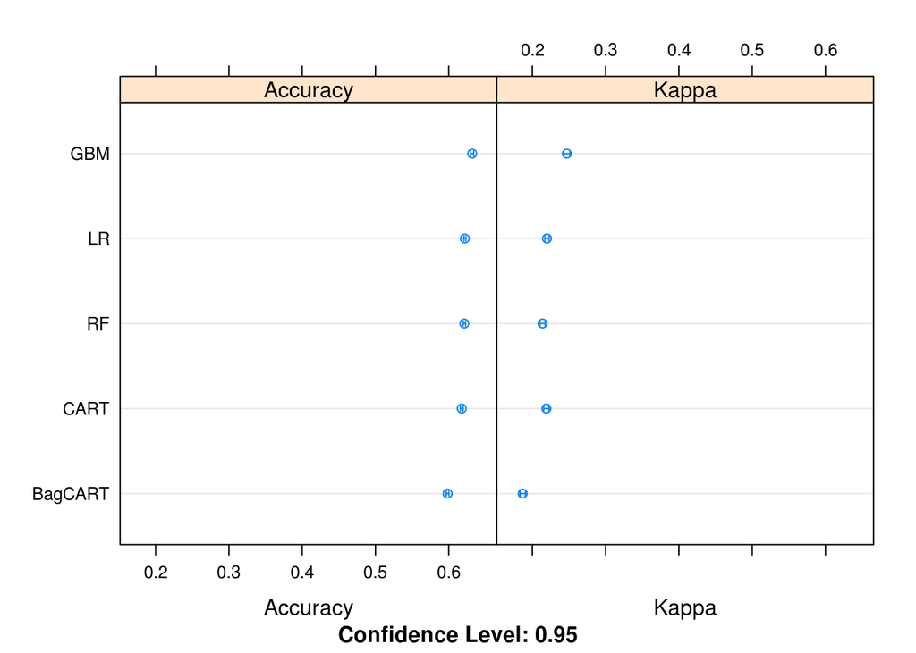

```r
dotplot(results)
```

```r
cat('The average accuracy from all models is:',
    mean(c(results$values$`LR~Accuracy`,results$values$`CART~Accuracy`,results$values$`BagCART~Accuracy`,results$values$`RF~Accuracy`,results$values$`GBM~Accuracy`)))
```

```
## The average accuracy from all models is: 0.6182883
```

## 5. Improve Accuracy or Results

After we achieve a short list of machine learning algorithms with good level of accuracy, we can leverage ways to improve the accuracy of the models.

### 5.a) Algorithm Tuning

Finally, we will tune the best-performing algorithms from each group further and see whether we can get more accuracy out of them.

```r
# Tuning algorithm #1 - Logistic Regression
# Logistic Regression has no special tuning parameters, so we are skipping this section.
email_notify(paste("Algorithm #1 tuning has begun!",date()))
```

```
## [1] "Java-Object{org.apache.commons.mail.SimpleEmail@6ea12c19}"
```

```r
startTimeModule <- proc.time()
set.seed(seedNum)
fit.final1 <- fit.glm
print(fit.final1)
```

```
## Generalized Linear Model
##
## 71237 samples
##    41 predictor
##     2 classes: '0', '1'
##
## No pre-processing
## Resampling: Cross-Validated (10 fold, repeated 3 times)
## Summary of sample sizes: 64113, 64114, 64114, 64114, 64113, 64113, ...
## Resampling results:
##
##   Accuracy   Kappa
##   0.6219849  0.219962
```

```r
proc.time()-startTimeModule
```

```
##    user  system elapsed
##   0.007   0.000   0.007
```

```r
email_notify(paste("Algorithm #1 tuning completed!",date()))
```

```
## [1] "Java-Object{org.apache.commons.mail.SimpleEmail@573f2bb1}"
```

```r
# Tuning algorithm #2 - Gradient Boosting
email_notify(paste("Algorithm #2 tuning has begun!",date()))
```

```
## [1] "Java-Object{org.apache.commons.mail.SimpleEmail@5dfcfece}"
```

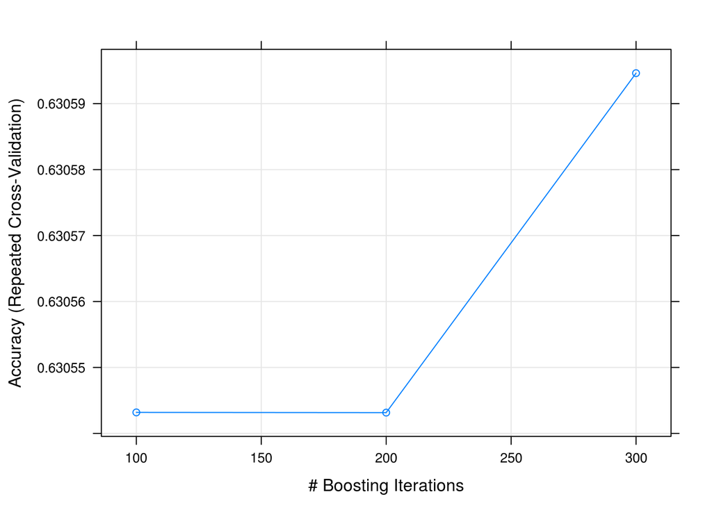

```r
startTimeModule <- proc.time()
set.seed(seedNum)
grid <- expand.grid(nrounds=c(100,200,300), max_depth=3, eta=0.3, gamma=0, colsample_bytree=0.6, min_child_weight=1, subsample=1)
fit.final2 <- train(targetVar~., data=xy_train, method="xgbTree", metric=metricTarget, tuneGrid=grid, trControl=control, verbose=F)
plot(fit.final2)
```

```r
print(fit.final2)
```

[output not shown]

```r
proc.time()-startTimeModule
```

```
##     user   system  elapsed
## 1031.341    2.600  702.939
```

```r
email_notify(paste("Algorithm #2 tuning completed!",date()))
```

```
## [1] "Java-Object{org.apache.commons.mail.SimpleEmail@5034c75a}"
```

### 5.d) Compare Algorithms After Tuning

```r
results <- resamples(list(LR=fit.final1, XGB=fit.final2))
summary(results)
```

```
##
## Call:
## summary.resamples(object = results)
##
## Models: LR, XGB
## Number of resamples: 30
##
## Accuracy
##          Min.   1st Qu.    Median      Mean   3rd Qu.      Max. NA's
## LR  0.6147368 0.6191262 0.6217184 0.6219849 0.6244955 0.6302639    0
## XGB 0.6166480 0.6270092 0.6321775 0.6305946 0.6340856 0.6406513    0
##
## Kappa
##          Min.   1st Qu.    Median      Mean   3rd Qu.      Max. NA's
## LR  0.2044843 0.2143051 0.2191605 0.2199620 0.2251960 0.2377834    0
## XGB 0.2169728 0.2376424 0.2490285 0.2456096 0.2534079 0.2664794    0
```

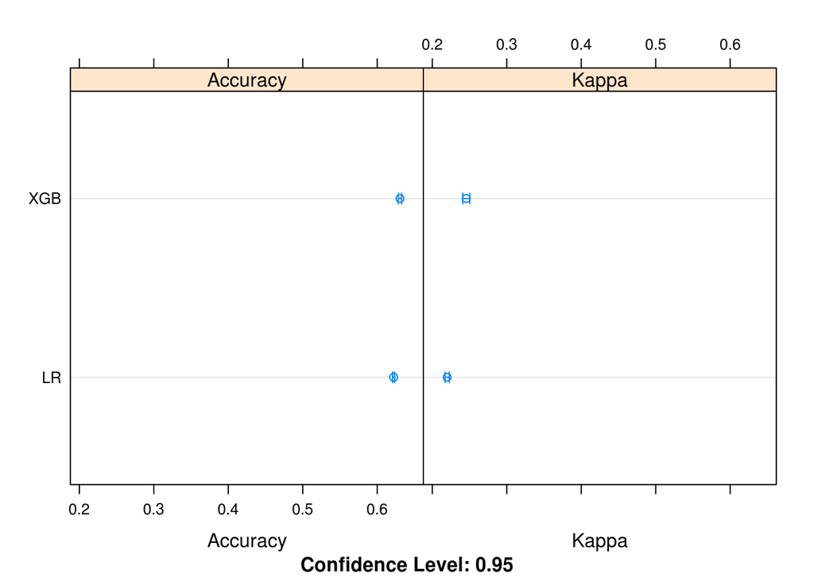

```r
dotplot(results)
```

## 6. Finalize Model and Present Results

Once we have narrow down to a model that we believe can make accurate predictions on unseen data, we are ready to finalize it. Finalizing a model may involve sub-tasks such as:

- Using an optimal model tuned to make predictions on unseen data.
- Creating a standalone model using the tuned parameters
- Saving an optimal model to file for later use.

```r
email_notify(paste("Model Validation and Final Model Creation has begun!",date()))
```

```
## [1] "Java-Object{org.apache.commons.mail.SimpleEmail@4f933fd1}"
```

### 6.a) Predictions on validation dataset

```r
predictions <- predict(fit.final2, newdata=xy_test)
confusionMatrix(predictions, y_test)
```

```
## Confusion Matrix and Statistics
##
##           Reference
## Prediction     0     1
##          0 12215  7065
##          1  4244  7005
##
##                Accuracy : 0.6296
##                  95% CI : (0.6241, 0.635)
##     No Information Rate : 0.5391
##     P-Value [Acc > NIR] : < 2.2e-16
##
##                   Kappa : 0.2436
##
##  Mcnemar's Test P-Value : < 2.2e-16
##
##             Sensitivity : 0.7421
##             Specificity : 0.4979
##          Pos Pred Value : 0.6336
##          Neg Pred Value : 0.6227
##              Prevalence : 0.5391
##          Detection Rate : 0.4001
##    Detection Prevalence : 0.6315
##       Balanced Accuracy : 0.6200
##
##        'Positive' Class : 0
##
```

### 6.b) Create standalone model on entire training dataset

```r
startTimeModule <- proc.time()
library(xgboost)
set.seed(seedNum)

# Combining the training and test datasets to form the original dataset that will be used for training the final model
xy_complete <- rbind(xy_train, xy_test)
y_final <-xy_complete$targetVar
xy_complete$targetVar <- NULL
x_final <- as.matrix(xy_complete)

# finalModel <- xgboost(data=x_final, label=y_final, nrounds=300, max_depth=3, eta=0.3, gamma=0, colsample_bytree=0.6, min_child_weight=1, subsample=1)
# summary(finalModel)
proc.time()-startTimeModule
```

```
##    user  system elapsed
##   0.066   0.000   0.067
```

### 6.c) Save model for later use

```r
#saveRDS(finalModel, "./finalModel_MultiClass.rds")
```

```r
email_notify(paste("Model Validation and Final Model Creation Completed!",date()))
```

```
## [1] "Java-Object{org.apache.commons.mail.SimpleEmail@1593948d}"
```

```r
proc.time()-startTimeScript
```

```
##      user    system   elapsed
## 59128.570   184.625 53665.914
```